# Flights Data Exploration

## Ainur Artay

## Preliminary Wrangling

```python
# import all packages and set plots to be embedded inline
import numpy as np
import pandas as pd
import matplotlib.pyplot as plt
import seaborn as sb
import os
import timeit
import glob
pd.set_option('display.max_columns', 500)

%matplotlib inline
```

```python
# load in the dataset into pandas dataframe
flights_2008 = pd.read_csv("2008.csv", dtype={'DepTime':str, "CRSDepTime":str, "ArrTime":str, "CRSArrTime":str})
```

```python
flights = flights_2008.copy()
```

```python
flights.info(null_counts=True)
```

```
<class 'pandas.core.frame.DataFrame'>
RangeIndex: 2389217 entries, 0 to 2389216
Data columns (total 29 columns):
Year                 2389217 non-null int64
Month                2389217 non-null int64
DayofMonth           2389217 non-null int64
DayOfWeek            2389217 non-null int64
DepTime              2324775 non-null object
CRSDepTime           2389217 non-null object
ArrTime              2319121 non-null object
CRSArrTime           2389217 non-null object
UniqueCarrier        2389217 non-null object
FlightNum            2389217 non-null int64
TailNum              2346765 non-null object
ActualElapsedTime    2319121 non-null float64
CRSElapsedTime       2388810 non-null float64
AirTime              2319121 non-null float64
ArrDelay             2319121 non-null float64
DepDelay             2324775 non-null float64
Origin               2389217 non-null object
Dest                 2389217 non-null object
Distance             2389217 non-null int64
TaxiIn               2319121 non-null float64
TaxiOut              2324775 non-null float64
Cancelled            2389217 non-null int64
CancellationCode     64442 non-null object
Diverted             2389217 non-null int64
CarrierDelay         584583 non-null float64
WeatherDelay         584583 non-null float64
NASDelay             584583 non-null float64
SecurityDelay        584583 non-null float64
LateAircraftDelay    584583 non-null float64
dtypes: float64(12), int64(8), object(9)
memory usage: 528.6+ MB
```

**What are the wrangling points?**

- A column calculating duration of the delays will be created;
- Therefore rows with null values in time columns will be removed;
- Duplicate rows will be deleted.

```python
# delete duplicsted rows
print(flights.duplicated().sum())
flights = flights.drop_duplicates()
```

```
4
```

```python
# delete unnecessary columns
flights = flights.drop(['Year', 'Cancelled', 'CancellationCode', 'Diverted'], axis = 1)
```

```python
# add a column "delay_elapsed"
flights['delay_elapsed'] = flights.ActualElapsedTime - flights.CRSElapsedTime
flights.head()
```

|  | Month | DayofMonth | DayOfWeek | DepTime | CRSDepTime | ArrTime | CRSArrTime | UniqueCarrier | FlightNum | TailNum | ActualElapsedTime | CRSElapsedTime | AirTime | ArrDelay | DepDelay | Origin | Dest | Distance | TaxiIn | TaxiOut | CarrierDelay | WeatherDelay | NASDelay | SecurityDelay | LateAircraftDelay | depay_elapsed | delay_elapsed |
| --- | --- | --- | --- | --- | --- | --- | --- | --- | --- | --- | --- | --- | --- | --- | --- | --- | --- | --- | --- | --- | --- | --- | --- | --- | --- | --- | --- |
| 0 | 1 | 3 | 4 | 1343 | 1325 | 1451 | 1435 | WN | 588 | N240WN | 68.0 | 70.0 | 55.0 | 16.0 | 18.0 | HOU | LIT | 393 | 4.0 | 9.0 | 16.0 | 0.0 | 0.0 | 0.0 | 0.0 | -2.0 | -2.0 |
| 1 | 1 | 3 | 4 | 1125 | 1120 | 1247 | 1245 | WN | 1343 | N523SW | 82.0 | 85.0 | 71.0 | 2.0 | 5.0 | HOU | MAF | 441 | 3.0 | 8.0 | NaN | NaN | NaN | NaN | NaN | -3.0 | -3.0 |
| 2 | 1 | 3 | 4 | 2009 | 2015 | 2136 | 2140 | WN | 3841 | N280WN | 87.0 | 85.0 | 71.0 | -4.0 | -6.0 | HOU | MAF | 441 | 2.0 | 14.0 | NaN | NaN | NaN | NaN | NaN | 2.0 | 2.0 |
| 3 | 1 | 3 | 4 | 903 | 855 | 1203 | 1205 | WN | 3 | N308SA | 120.0 | 130.0 | 108.0 | -2.0 | 8.0 | HOU | MCO | 848 | 5.0 | 7.0 | NaN | NaN | NaN | NaN | NaN | -10.0 | -10.0 |
| 4 | 1 | 3 | 4 | 1423 | 1400 | 1726 | 1710 | WN | 25 | N462WN | 123.0 | 130.0 | 107.0 | 16.0 | 23.0 | HOU | MCO | 848 | 6.0 | 10.0 | 16.0 | 0.0 | 0.0 | 0.0 | 0.0 | -7.0 | -7.0 |

```python
flights[(flights.ArrDelay - flights.DepDelay - flights.delay_elapsed) < -3]
```

|  | Month | DayofMonth | DayOfWeek | DepTime | CRSDepTime | ArrTime | CRSArrTime | UniqueCarrier | FlightNum | TailNum | ActualElapsedTime | CRSElapsedTime | AirTime | ArrDelay | DepDelay | Origin | Dest | Distance | TaxiIn | TaxiOut | CarrierDelay | WeatherDelay | NASDelay | SecurityDelay | LateAircraftDelay | depay_elapsed | delay_elapsed |
| --- | --- | --- | --- | --- | --- | --- | --- | --- | --- | --- | --- | --- | --- | --- | --- | --- | --- | --- | --- | --- | --- | --- | --- | --- | --- | --- | --- |

```python
# confirm that ArrDelay = DepDelay + delay_elapsed (allowing erros within 3 minutes)

assert flights[(flights.ArrDelay - flights.DepDelay - flights.delay_elapsed < -3) | (flights.ArrDelay - flights.DepDelay - flights.delay_elapsed > 3)].shape[0] == 0
```

```python
# descriptive statistics for numeric variables
flights.describe()
```

|  | Month | DayofMonth | DayOfWeek | FlightNum | ActualElapsedTime | CRSElapsedTime | AirTime | ArrDelay | DepDelay | Distance | TaxiIn | TaxiOut | CarrierDelay | WeatherDelay | NASDelay | SecurityDelay | LateAircraftDelay | depay_elapsed | delay_elapsed |
| --- | --- | --- | --- | --- | --- | --- | --- | --- | --- | --- | --- | --- | --- | --- | --- | --- | --- | --- | --- |
| count | 2.389213e+06 | 2.389213e+06 | 2.389213e+06 | 2.389213e+06 | 2.319117e+06 | 2.388806e+06 | 2.319117e+06 | 2.319117e+06 | 2.324771e+06 | 2.389213e+06 | 2.319117e+06 | 2.324771e+06 | 584581.000000 | 584581.000000 | 584581.000000 | 584581.000000 | 584581.000000 | 2.319117e+06 | 2.319117e+06 |
| mean | 2.505010e+00 | 1.566384e+01 | 3.909625e+00 | 2.213890e+03 | 1.286188e+02 | 1.293775e+02 | 1.051016e+02 | 1.027355e+01 | 1.143634e+01 | 7.261584e+02 | 6.839860e+00 | 1.668585e+01 | 15.752934 | 2.938253 | 16.158442 | 0.080459 | 20.976782 | -1.115588e+00 | -1.115588e+00 |
| std | 1.121493e+00 | 8.750398e+00 | 1.980432e+00 | 1.951393e+03 | 7.025303e+01 | 6.948246e+01 | 6.766801e+01 | 3.963431e+01 | 3.653231e+01 | 5.571763e+02 | 4.846439e+00 | 1.102906e+01 | 40.035534 | 19.166694 | 30.534190 | 1.742582 | 38.617200 | 1.420628e+01 | 1.420628e+01 |
| min | 1.000000e+00 | 1.000000e+00 | 1.000000e+00 | 1.000000e+00 | 1.400000e+01 | -2.500000e+01 | 0.000000e+00 | -9.100000e+01 | -9.200000e+01 | 1.700000e+01 | 0.000000e+00 | 0.000000e+00 | 0.000000 | 0.000000 | 0.000000 | 0.000000 | 0.000000 | -1.510000e+02 | -1.510000e+02 |
| 25% | 1.000000e+00 | 8.000000e+00 | 2.000000e+00 | 6.050000e+02 | 7.800000e+01 | 8.000000e+01 | 5.600000e+01 | -9.000000e+00 | -4.000000e+00 | 3.250000e+02 | 4.000000e+00 | 1.000000e+01 | 0.000000 | 0.000000 | 0.000000 | 0.000000 | 0.000000 | -9.000000e+00 | -9.000000e+00 |
| 50% | 3.000000e+00 | 1.600000e+01 | 4.000000e+00 | 1.544000e+03 | 1.110000e+02 | 1.110000e+02 | 8.700000e+01 | 0.000000e+00 | 0.000000e+00 | 5.830000e+02 | 6.000000e+00 | 1.400000e+01 | 0.000000 | 0.000000 | 5.000000 | 0.000000 | 0.000000 | -3.000000e+00 | -3.000000e+00 |
| 75% | 4.000000e+00 | 2.300000e+01 | 6.000000e+00 | 3.631000e+03 | 1.600000e+02 | 1.600000e+02 | 1.340000e+02 | 1.500000e+01 | 1.100000e+01 | 9.570000e+02 | 8.000000e+00 | 1.900000e+01 | 16.000000 | 0.000000 | 20.000000 | 0.000000 | 27.000000 | 5.000000e+00 | 5.000000e+00 |
| max | 4.000000e+00 | 3.100000e+01 | 7.000000e+00 | 9.741000e+03 | 9.050000e+02 | 1.435000e+03 | 8.860000e+02 | 2.461000e+03 | 2.467000e+03 | 4.962000e+03 | 2.130000e+02 | 3.830000e+02 | 2436.000000 | 1148.000000 | 1357.000000 | 392.000000 | 1254.000000 | 5.700000e+02 | 5.700000e+02 |

```python
flights.head()
```

|  | Month | DayofMonth | DayOfWeek | DepTime | CRSDepTime | ArrTime | CRSArrTime | UniqueCarrier | FlightNum | TailNum | ActualElapsedTime | CRSElapsedTime | AirTime | ArrDelay | DepDelay | Origin | Dest | Distance | TaxiIn | TaxiOut | CarrierDelay | WeatherDelay | NASDelay | SecurityDelay | LateAircraftDelay | depay_elapsed | delay_elapsed |
| --- | --- | --- | --- | --- | --- | --- | --- | --- | --- | --- | --- | --- | --- | --- | --- | --- | --- | --- | --- | --- | --- | --- | --- | --- | --- | --- | --- |
| 0 | 1 | 3 | 4 | 1343 | 1325 | 1451 | 1435 | WN | 588 | N240WN | 68.0 | 70.0 | 55.0 | 16.0 | 18.0 | HOU | LIT | 393 | 4.0 | 9.0 | 16.0 | 0.0 | 0.0 | 0.0 | 0.0 | -2.0 | -2.0 |
| 1 | 1 | 3 | 4 | 1125 | 1120 | 1247 | 1245 | WN | 1343 | N523SW | 82.0 | 85.0 | 71.0 | 2.0 | 5.0 | HOU | MAF | 441 | 3.0 | 8.0 | NaN | NaN | NaN | NaN | NaN | -3.0 | -3.0 |
| 2 | 1 | 3 | 4 | 2009 | 2015 | 2136 | 2140 | WN | 3841 | N280WN | 87.0 | 85.0 | 71.0 | -4.0 | -6.0 | HOU | MAF | 441 | 2.0 | 14.0 | NaN | NaN | NaN | NaN | NaN | 2.0 | 2.0 |
| 3 | 1 | 3 | 4 | 903 | 855 | 1203 | 1205 | WN | 3 | N308SA | 120.0 | 130.0 | 108.0 | -2.0 | 8.0 | HOU | MCO | 848 | 5.0 | 7.0 | NaN | NaN | NaN | NaN | NaN | -10.0 | -10.0 |
| 4 | 1 | 3 | 4 | 1423 | 1400 | 1726 | 1710 | WN | 25 | N462WN | 123.0 | 130.0 | 107.0 | 16.0 | 23.0 | HOU | MCO | 848 | 6.0 | 10.0 | 16.0 | 0.0 | 0.0 | 0.0 | 0.0 | -7.0 | -7.0 |

### What is the structure of your dataset?

> Now, there are rows of flight data in the dataset with 29 features originally.  
> Variable descriptions Name Description 1 Month 1-12  
> 2 DayofMonth 1-31  
> 3 DayOfWeek 1 (Monday) - 7 (Sunday)  
> 4 DepTime actual departure time (local, hhmm)  
> 5 CRSDepTime scheduled departure time (local, hhmm)  
> 6 ArrTime actual arrival time (local, hhmm)  
> 7 CRSArrTime scheduled arrival time (local, hhmm)  
> 8 UniqueCarrier unique carrier code  
> 9 FlightNum flight number  
> 10 TailNum plane tail number  
> 11 ActualElapsedTime (actual) in minutes  
> 12 CRSElapsedTime (scheduled) in minutes  
> 13 AirTime in minutes 14 ArrDelay (Difference in minutes between scheduled and actual arrival time)  
> 15 DepDelay (Difference in minutes between scheduled and actual departure time. )  
> 16 Origin origin IATA airport code  
> 17 Dest destination IATA airport code  
> (Code assigned by IATA and commonly used to identify a carrier. As the same code may have been assigned to different carriers over time, the code is not always unique.) 18 Distance in miles 19 TaxiIn taxi in time, in minutes  
> 20 TaxiOut taxi out time, in minutes  
> 21 CarrierDelay in minutes  
> 22 WeatherDelay in minutes  
> 23 NASDelay (National Air System Delay) in minutes  
> 24 SecurityDelay in minutes  
> 25 LateAircraftDelay in minutes

> A reference for delay definitions: [here](http://aspmhelp.faa.gov/index.php/Types_of_Delay)
> - Carrier Delay  
>   Carrier delay is within the control of the air carrier. Examples of occurrences that may determine carrier delay are: aircraft cleaning, aircraft damage, awaiting the arrival of connecting passengers or crew, baggage, bird strike, cargo loading, catering, computer, outage-carrier equipment, crew legality (pilot or attendant rest), damage by hazardous goods, engineering inspection, fueling, handling disabled passengers, late crew, lavatory servicing, maintenance, oversales, potable water servicing, removal of unruly passenger, slow boarding or seating, stowing carry-on baggage, weight and balance delays.
> - Late Arrival Delay  
>   Arrival delay at an airport due to the late arrival of the same aircraft at a previous airport. The ripple effect of an earlier delay at downstream airports is referred to as delay propagation.
> - NAS Delay  
>   Delay that is within the control of the National Airspace System (NAS) may include: non-extreme weather conditions, airport operations, heavy traffic volume, air traffic control, etc. Delays that occur after Actual Gate Out are usually attributed to the NAS and are also reported through OPSNET.
> - Security Delay  
>   Security delay is caused by evacuation of a terminal or concourse, re-boarding of aircraft because of security breach, inoperative screening equipment and/or long lines in excess of 29 minutes at screening areas.
> - Weather Delay  
>   Weather delay is caused by extreme or hazardous weather conditions that are forecasted or manifest themselves on point of departure, enroute, or on point of arrival.

### What is/are the main feature(s) of interest in your dataset?

> - What causes the longer delays?

### What features in the dataset do you think will help support your investigation into your feature(s) of interest?

> - 2 factors of delay (*departure delay + elapsed time extension*)
>   - arrival delay = ArrDelay = ArrTime - CRSArrTime
>   - departure delay = DepDelay = DepTime - CRSDepTime
>   - elapsed time extension = ActualElapsedTime - CRSElapsedTime
> - Distance
> - 5 delay factors given in the dataset
>   - WeatherDelay, NAS Delay, SecurityDelay, LateAircraftDelay

## Univariate Exploration

> I'll start by looking at the distrbution of the main variables of interest:
> 1. Disatance
> 2. AirTime
> 3. ArrDelay
> 4. DepDelay
> 5. delay_elapsed

### 1. Distance

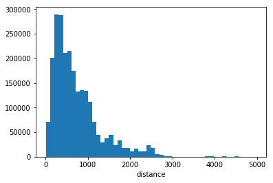

```python
plt.hist(data = flights, x = "Distance", bins = 50)
plt.xlabel("distance");
```

```python
# Majority of the flights are relatively short distance, up to 1000 miles.
# The extremely high values  should be paid more attention. These can be outliers.
flights[flights.Distance > 3000].sample(10)
```

|  | Month | DayofMonth | DayOfWeek | DepTime | CRSDepTime | ArrTime | CRSArrTime | UniqueCarrier | FlightNum | TailNum | ActualElapsedTime | CRSElapsedTime | AirTime | ArrDelay | DepDelay | Origin | Dest | Distance | TaxiIn | TaxiOut | CarrierDelay | WeatherDelay | NASDelay | SecurityDelay | LateAircraftDelay | depay_elapsed | delay_elapsed |
| --- | --- | --- | --- | --- | --- | --- | --- | --- | --- | --- | --- | --- | --- | --- | --- | --- | --- | --- | --- | --- | --- | --- | --- | --- | --- | --- | --- |
| 2262452 | 4 | 21 | 1 | 856 | 900 | 1301 | 1309 | AA | 73 | N373AA | 545.0 | 549.0 | 531.0 | -8.0 | -4.0 | ORD | HNL | 4243 | 3.0 | 11.0 | NaN | NaN | NaN | NaN | NaN | -4.0 | -4.0 |
| 1146598 | 2 | 19 | 2 | 2244 | 2245 | 1306 | 1310 | CO | 14 | N67052 | 562.0 | 565.0 | 529.0 | -4.0 | -1.0 | HNL | EWR | 4962 | 15.0 | 18.0 | NaN | NaN | NaN | NaN | NaN | -3.0 | -3.0 |
| 1742865 | 3 | 3 | 1 | 2221 | 2225 | 1001 | 955 | CO | 72 | N76065 | 460.0 | 450.0 | 436.0 | 6.0 | -4.0 | HNL | IAH | 3904 | 5.0 | 19.0 | NaN | NaN | NaN | NaN | NaN | 10.0 | 10.0 |
| 1396175 | 3 | 10 | 1 | 935 | 945 | 1327 | 1353 | UA | 3 | N214UA | 532.0 | 548.0 | 501.0 | -26.0 | -10.0 | ORD | OGG | 4184 | 4.0 | 27.0 | NaN | NaN | NaN | NaN | NaN | -16.0 | -16.0 |
| 570330 | 1 | 20 | 7 | 1332 | 1320 | 1939 | 1920 | CO | 15 | N67052 | 667.0 | 660.0 | 626.0 | 19.0 | 12.0 | EWR | HNL | 4962 | 10.0 | 31.0 | 0.0 | 0.0 | 7.0 | 0.0 | 12.0 | 7.0 | 7.0 |
| 477348 | 1 | 20 | 7 | 1204 | 1210 | 1615 | 1630 | AA | 7 | N381AA | 491.0 | 500.0 | 476.0 | -15.0 | -6.0 | DFW | OGG | 3711 | 4.0 | 11.0 | NaN | NaN | NaN | NaN | NaN | -9.0 | -9.0 |
| 478061 | 1 | 1 | 2 | 1744 | 1745 | 636 | 555 | AA | 72 | N381AA | 532.0 | 490.0 | 480.0 | 41.0 | -1.0 | HNL | ORD | 4243 | 15.0 | 37.0 | 0.0 | 0.0 | 41.0 | 0.0 | 0.0 | 42.0 | 42.0 |
| 1054694 | 2 | 7 | 4 | 1140 | 1140 | 1615 | 1615 | AA | 123 | N347AA | 515.0 | 515.0 | 494.0 | 0.0 | 0.0 | DFW | HNL | 3784 | 6.0 | 15.0 | NaN | NaN | NaN | NaN | NaN | 0.0 | 0.0 |
| 810683 | 2 | 19 | 2 | 1704 | 1710 | 445 | 504 | UA | 2 | N214UA | 461.0 | 474.0 | 443.0 | -19.0 | -6.0 | HNL | ORD | 4243 | 4.0 | 14.0 | NaN | NaN | NaN | NaN | NaN | -13.0 | -13.0 |
| 2261697 | 4 | 18 | 5 | 1217 | 1210 | 1522 | 1520 | AA | 7 | N386AA | 485.0 | 490.0 | 465.0 | 2.0 | 7.0 | DFW | OGG | 3711 | 5.0 | 15.0 | NaN | NaN | NaN | NaN | NaN | -5.0 | -5.0 |

```python
# The origin/destination codes repeatedly indicate HNL, OGG codes, which seems to be Hawaiian airports:
hawaii = ["HNL", "OGG", "KOA"]
assert flights[(flights.Distance > 3500) & (~flights.Origin.isin(hawaii)) & (~flights.Dest.isin(hawaii)) ].shape[0] == 0
```

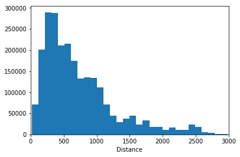

```python
# As the right tail comprises of few data ponts, we can "zoom" into the distance range 0-3000:
plt.hist(data=flights, x="Distance", bins=50)
plt.xlabel("Distance")
plt.xlim([0,3000]);
```

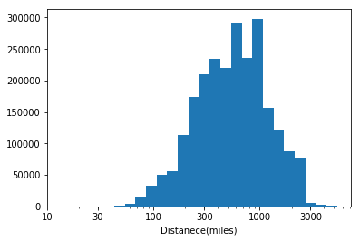

```python
# The data in the log scale:
bin = 10 ** np.arange(np.log10(flights.Distance.min()), np.log10(flights.Distance.max())+0.1, 0.1)
plt.hist(data=flights, x="Distance", bins=bin)
plt.xscale("log")
plt.xlabel("Distanece(miles)")
plt.xticks([10,30,100,300,1000,3000],[10,30,100,300,1000,3000]);
```

> - Most of the flights are relatively short-distance flights
> - The log-scale view reveals resemblance of the distance distribution to bell curve, i.e. normal distribution, with the mean between 300-1000 miles.

### 2. Air time

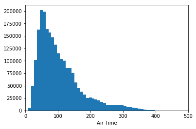

```python
plt.hist(data = flights, x = "AirTime", bins = 100)
plt.xlabel("Air Time")
plt.xlim([0,500]);
```

> - AirTime is similar to Distance in the distribution
> - Looks like the air time does not exceeds 400 minutes, which is a little over 6.5 hours. This could be explained by technical limitations of air cargos and few long distance flights (eg. to/from Hawaii)

```python
# Lets check the second part of the hypothesis above
assert flights[(flights.AirTime > 600) & (~flights.Origin.isin(hawaii)) & (~flights.Dest.isin(hawaii))].shape[0] == 0
```

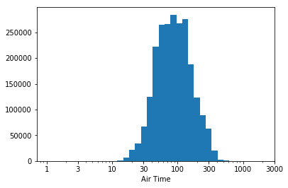

```python
# Removing rows with 0 values for AirTime and creating a histogram on log-scale
df[df.AirTime != 0].shape[0]
df = df[df.AirTime != 0]
bin = 10 ** np.arange(np.log10(df.AirTime.min()), np.log10(df.AirTime.max())+0.09, 0.09)
plt.hist(data=df, x="AirTime", bins=bin)
plt.xscale("log")
plt.xticks([1,3,10,30,100,300,1000,3000],[1,3,10,30,100,300,1000,3000])
plt.xlabel("Air Time");
```

### 3. Arrival delay

```
(-100, 250)
```

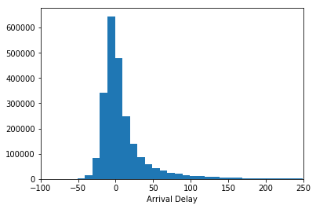

```python
plt.hist(data=flights, x="ArrDelay", bins=np.arange(flights.ArrDelay.min(),flights.ArrDelay.max()+10,10) )
plt.xlabel("Arrival Delay")
plt.xlim([-100,250])
```

```python
# Let's examine extreme values. Extremely high ArrDelay values, i.e. significantly delayed arrivals
flights[(flights.ArrDelay > 2000)]
```

|  | Month | DayofMonth | DayOfWeek | DepTime | CRSDepTime | ArrTime | CRSArrTime | UniqueCarrier | FlightNum | TailNum | ActualElapsedTime | CRSElapsedTime | AirTime | ArrDelay | DepDelay | Origin | Dest | Distance | TaxiIn | TaxiOut | CarrierDelay | WeatherDelay | NASDelay | SecurityDelay | LateAircraftDelay | depay_elapsed | delay_elapsed |
| --- | --- | --- | --- | --- | --- | --- | --- | --- | --- | --- | --- | --- | --- | --- | --- | --- | --- | --- | --- | --- | --- | --- | --- | --- | --- | --- | --- |
| 1018504 | 2 | 3 | 7 | 1117 | 1820 | 2256 | 555 | NW | 808 | N817NW | 459.0 | 455.0 | 437.0 | 2461.0 | 2457.0 | HNL | MSP | 3972 | 6.0 | 16.0 | 1455.0 | 0.0 | 4.0 | 0.0 | 1002.0 | 4.0 | 4.0 |
| 2235384 | 4 | 10 | 4 | 724 | 1417 | 858 | 1605 | NW | 1699 | N3324L | 154.0 | 168.0 | 132.0 | 2453.0 | 2467.0 | CLT | MSP | 930 | 8.0 | 14.0 | 2436.0 | 0.0 | 0.0 | 0.0 | 17.0 | -14.0 | -14.0 |

```python
# Extremely low values, i.e early arrivals
flights[(flights.ArrDelay<-100)]
```

|  | Month | DayofMonth | DayOfWeek | DepTime | CRSDepTime | ArrTime | CRSArrTime | UniqueCarrier | FlightNum | TailNum | ActualElapsedTime | CRSElapsedTime | AirTime | ArrDelay | DepDelay | Origin | Dest | Distance | TaxiIn | TaxiOut | CarrierDelay | WeatherDelay | NASDelay | SecurityDelay | LateAircraftDelay | depay_elapsed | delay_elapsed |
| --- | --- | --- | --- | --- | --- | --- | --- | --- | --- | --- | --- | --- | --- | --- | --- | --- | --- | --- | --- | --- | --- | --- | --- | --- | --- | --- | --- |

> The histogram **"early arrivals" makes sense** as the planes do not depart early than the scheduled time and there's little room for the plane to significantly exceed the planned in air speed. The delayed arrivals are more interesting as they can be caused **i) on land**, i.e. delayed departure; and **ii) in air**, i.e. weather conditions which make planes take extra time before landing or change landing airports. This will be analyzed by examining 2 variables: **DepDelay** and **delay_elapesd**. The distribution is right-skewed with the **mean** around 0.

### 4. Departure Delay

```
(-100, 250)
```

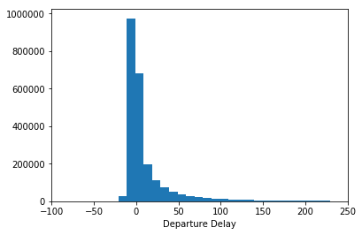

```python
plt.hist(data=flights, x="DepDelay",bins=np.arange(df.ArrDelay.min(),df.ArrDelay.max()+10,10))
plt.xlabel("Departure Delay")
plt.xlim([-100,250])
```

```python
flights[flights.DepDelay < -50]
```

[output not shown]

```python
flights[flights.DepDelay > 2000]
```

[output not shown]

> The distribution of DepDelay departures is right-skewed, with the mean around 0, which is reasonable (as discussed above).

### 5. Elapsed time delay

```
(-100, 250)
```

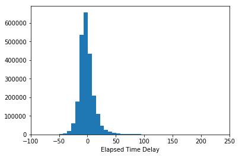

```python
plt.hist(data=flights, x="delay_elapsed", bins = 100)
plt.xlabel("Elapsed Time Delay")
plt.xlim([-100,250])
```

```python
flights[flights.delay_elapsed < -100]
```

|  | Month | DayofMonth | DayOfWeek | DepTime | CRSDepTime | ArrTime | CRSArrTime | UniqueCarrier | FlightNum | TailNum | ActualElapsedTime | CRSElapsedTime | AirTime | ArrDelay | DepDelay | Origin | Dest | Distance | TaxiIn | TaxiOut | CarrierDelay | WeatherDelay | NASDelay | SecurityDelay | LateAircraftDelay | depay_elapsed | delay_elapsed |
| --- | --- | --- | --- | --- | --- | --- | --- | --- | --- | --- | --- | --- | --- | --- | --- | --- | --- | --- | --- | --- | --- | --- | --- | --- | --- | --- | --- |
| 682431 | 2 | 26 | 2 | 2116 | 1940 | 2130 | 2135 | WN | 1830 | N747SA | 134.0 | 235.0 | 125.0 | -5.0 | 96.0 | MCI | SMF | 1442 | 4.0 | 5.0 | NaN | NaN | NaN | NaN | NaN | -101.0 | -101.0 |
| 1637523 | 3 | 9 | 7 | 1823 | 1420 | 2051 | 1910 | 9E | 2029 | 91469E | 148.0 | 290.0 | 90.0 | 101.0 | 243.0 | PIT | ATL | 526 | 32.0 | 26.0 | 0.0 | 0.0 | 0.0 | 0.0 | 101.0 | -142.0 | -142.0 |
| 1705608 | 3 | 8 | 6 | 1256 | 1135 | 1627 | 1737 | AA | 2093 | N3CDAA | 211.0 | 362.0 | 177.0 | 1370.0 | 1521.0 | LGA | MIA | 1097 | 5.0 | 29.0 | 50.0 | 0.0 | 1289.0 | 0.0 | 31.0 | -151.0 | -151.0 |

```python
flights[flights.delay_elapsed>500]
```

|  | Month | DayofMonth | DayOfWeek | DepTime | CRSDepTime | ArrTime | CRSArrTime | UniqueCarrier | FlightNum | TailNum | ActualElapsedTime | CRSElapsedTime | AirTime | ArrDelay | DepDelay | Origin | Dest | Distance | TaxiIn | TaxiOut | CarrierDelay | WeatherDelay | NASDelay | SecurityDelay | LateAircraftDelay | depay_elapsed | delay_elapsed |
| --- | --- | --- | --- | --- | --- | --- | --- | --- | --- | --- | --- | --- | --- | --- | --- | --- | --- | --- | --- | --- | --- | --- | --- | --- | --- | --- | --- |
| 2160496 | 4 | 27 | 7 | 1343 | 1340 | 748 | 2215 | HA | 22 | N587HA | 905.0 | 335.0 | 886.0 | 573.0 | 3.0 | HNL | SEA | 2677 | 9.0 | 10.0 | 573.0 | 0.0 | 0.0 | 0.0 | 0.0 | 570.0 | 570.0 |

> It's interesting that delay_elapsed has 3 values below -100 minutes, while ArrDelay does not. In this case, it's reasonable to expect that these might have been flights where emergency landing were made as scheduled elapsed time is significantly longer that time in air and actual elapsed time. In 2 cases out of 3, there were significant arrival delays which also support this assumption. I will remove these from the dataframe as **outliers**.

```python
flights.drop(flights.index[[682431, 1637523, 1705608]])
```

|  | Month | DayofMonth | DayOfWeek | DepTime | CRSDepTime | ArrTime | CRSArrTime | UniqueCarrier | FlightNum | TailNum | ActualElapsedTime | CRSElapsedTime | AirTime | ArrDelay | DepDelay | Origin | Dest | Distance | TaxiIn | TaxiOut | CarrierDelay | WeatherDelay | NASDelay | SecurityDelay | LateAircraftDelay | depay_elapsed | delay_elapsed |
| --- | --- | --- | --- | --- | --- | --- | --- | --- | --- | --- | --- | --- | --- | --- | --- | --- | --- | --- | --- | --- | --- | --- | --- | --- | --- | --- | --- |
| 0 | 1 | 3 | 4 | 1343 | 1325 | 1451 | 1435 | WN | 588 | N240WN | 68.0 | 70.0 | 55.0 | 16.0 | 18.0 | HOU | LIT | 393 | 4.0 | 9.0 | 16.0 | 0.0 | 0.0 | 0.0 | 0.0 | -2.0 | -2.0 |
| 1 | 1 | 3 | 4 | 1125 | 1120 | 1247 | 1245 | WN | 1343 | N523SW | 82.0 | 85.0 | 71.0 | 2.0 | 5.0 | HOU | MAF | 441 | 3.0 | 8.0 | NaN | NaN | NaN | NaN | NaN | -3.0 | -3.0 |
| 2 | 1 | 3 | 4 | 2009 | 2015 | 2136 | 2140 | WN | 3841 | N280WN | 87.0 | 85.0 | 71.0 | -4.0 | -6.0 | HOU | MAF | 441 | 2.0 | 14.0 | NaN | NaN | NaN | NaN | NaN | 2.0 | 2.0 |
| 3 | 1 | 3 | 4 | 903 | 855 | 1203 | 1205 | WN | 3 | N308SA | 120.0 | 130.0 | 108.0 | -2.0 | 8.0 | HOU | MCO | 848 | 5.0 | 7.0 | NaN | NaN | NaN | NaN | NaN | -10.0 | -10.0 |
| 4 | 1 | 3 | 4 | 1423 | 1400 | 1726 | 1710 | WN | 25 | N462WN | 123.0 | 130.0 | 107.0 | 16.0 | 23.0 | HOU | MCO | 848 | 6.0 | 10.0 | 16.0 | 0.0 | 0.0 | 0.0 | 0.0 | -7.0 | -7.0 |
| 5 | 1 | 3 | 4 | 2024 | 2020 | 2325 | 2325 | WN | 51 | N483WN | 121.0 | 125.0 | 101.0 | 0.0 | 4.0 | HOU | MCO | 848 | 13.0 | 7.0 | NaN | NaN | NaN | NaN | NaN | -4.0 | -4.0 |
| 6 | 1 | 3 | 4 | 1753 | 1745 | 2053 | 2050 | WN | 940 | N493WN | 120.0 | 125.0 | 107.0 | 3.0 | 8.0 | HOU | MCO | 848 | 6.0 | 7.0 | NaN | NaN | NaN | NaN | NaN | -5.0 | -5.0 |
| 7 | 1 | 3 | 4 | 622 | 620 | 935 | 930 | WN | 2621 | N266WN | 133.0 | 130.0 | 107.0 | 5.0 | 2.0 | HOU | MCO | 848 | 7.0 | 19.0 | NaN | NaN | NaN | NaN | NaN | 3.0 | 3.0 |
| 8 | 1 | 3 | 4 | 1944 | 1945 | 2210 | 2215 | WN | 389 | N266WN | 146.0 | 150.0 | 124.0 | -5.0 | -1.0 | HOU | MDW | 937 | 7.0 | 15.0 | NaN | NaN | NaN | NaN | NaN | -4.0 | -4.0 |
| 9 | 1 | 3 | 4 | 1453 | 1425 | 1716 | 1650 | WN | 519 | N514SW | 143.0 | 145.0 | 124.0 | 26.0 | 28.0 | HOU | MDW | 937 | 6.0 | 13.0 | 11.0 | 0.0 | 0.0 | 0.0 | 15.0 | -2.0 | -2.0 |
| 10 | 1 | 3 | 4 | 2030 | 2015 | 2251 | 2245 | WN | 894 | N716SW | 141.0 | 150.0 | 122.0 | 6.0 | 15.0 | HOU | MDW | 937 | 11.0 | 8.0 | NaN | NaN | NaN | NaN | NaN | -9.0 | -9.0 |
| 11 | 1 | 3 | 4 | 708 | 615 | 936 | 840 | WN | 969 | N215WN | 148.0 | 145.0 | 128.0 | 56.0 | 53.0 | HOU | MDW | 937 | 10.0 | 10.0 | 53.0 | 0.0 | 3.0 | 0.0 | 0.0 | 3.0 | 3.0 |
| 12 | 1 | 3 | 4 | 1749 | 1730 | 2039 | 2000 | WN | 2174 | N623SW | 170.0 | 150.0 | 128.0 | 39.0 | 19.0 | HOU | MDW | 937 | 34.0 | 8.0 | 10.0 | 0.0 | 20.0 | 0.0 | 9.0 | 20.0 | 20.0 |
| 13 | 1 | 3 | 4 | 1217 | 1215 | 1431 | 1440 | WN | 2445 | N651SW | 134.0 | 145.0 | 124.0 | -9.0 | 2.0 | HOU | MDW | 937 | 4.0 | 6.0 | NaN | NaN | NaN | NaN | NaN | -11.0 | -11.0 |
| 14 | 1 | 3 | 4 | 954 | 940 | 1206 | 1205 | WN | 2974 | N447WN | 132.0 | 145.0 | 120.0 | 1.0 | 14.0 | HOU | MDW | 937 | 5.0 | 7.0 | NaN | NaN | NaN | NaN | NaN | -13.0 | -13.0 |
| 15 | 1 | 3 | 4 | 1758 | 1800 | 1854 | 1900 | WN | 41 | N240WN | 56.0 | 60.0 | 45.0 | -6.0 | -2.0 | HOU | MSY | 303 | 3.0 | 8.0 | NaN | NaN | NaN | NaN | NaN | -4.0 | -4.0 |
| 16 | 1 | 3 | 4 | 2210 | 2120 | 2305 | 2215 | WN | 78 | N268WN | 55.0 | 55.0 | 44.0 | 50.0 | 50.0 | HOU | MSY | 303 | 3.0 | 8.0 | 6.0 | 0.0 | 0.0 | 0.0 | 44.0 | 0.0 | 0.0 |
| 17 | 1 | 3 | 4 | 740 | 740 | 836 | 840 | WN | 311 | N504SW | 56.0 | 60.0 | 45.0 | -4.0 | 0.0 | HOU | MSY | 303 | 3.0 | 8.0 | NaN | NaN | NaN | NaN | NaN | -4.0 | -4.0 |
| 18 | 1 | 3 | 4 | 1011 | 1005 | 1116 | 1105 | WN | 521 | N332SW | 65.0 | 60.0 | 49.0 | 11.0 | 6.0 | HOU | MSY | 303 | 4.0 | 12.0 | NaN | NaN | NaN | NaN | NaN | 5.0 | 5.0 |
| 19 | 1 | 3 | 4 | 1612 | 1520 | 1707 | 1620 | WN | 714 | N305SW | 55.0 | 60.0 | 44.0 | 47.0 | 52.0 | HOU | MSY | 303 | 4.0 | 7.0 | 0.0 | 0.0 | 0.0 | 0.0 | 47.0 | -5.0 | -5.0 |
| 20 | 1 | 3 | 4 | 1124 | 1115 | 1229 | 1215 | WN | 788 | N426WN | 65.0 | 60.0 | 45.0 | 14.0 | 9.0 | HOU | MSY | 303 | 5.0 | 15.0 | NaN | NaN | NaN | NaN | NaN | 5.0 | 5.0 |
| 21 | 1 | 3 | 4 | 824 | 825 | 922 | 925 | WN | 880 | N523SW | 58.0 | 60.0 | 46.0 | -3.0 | -1.0 | HOU | MSY | 303 | 4.0 | 8.0 | NaN | NaN | NaN | NaN | NaN | -2.0 | -2.0 |
| 22 | 1 | 3 | 4 | 2112 | 2015 | 2207 | 2110 | WN | 1257 | N507SW | 55.0 | 55.0 | 44.0 | 57.0 | 57.0 | HOU | MSY | 303 | 4.0 | 7.0 | 0.0 | 0.0 | 0.0 | 0.0 | 57.0 | 0.0 | 0.0 |
| 23 | 1 | 3 | 4 | 641 | 640 | 737 | 740 | WN | 1317 | N366SW | 56.0 | 60.0 | 45.0 | -3.0 | 1.0 | HOU | MSY | 303 | 3.0 | 8.0 | NaN | NaN | NaN | NaN | NaN | -4.0 | -4.0 |
| 24 | 1 | 3 | 4 | 1713 | 1710 | 1810 | 1810 | WN | 1776 | N408WN | 57.0 | 60.0 | 43.0 | 0.0 | 3.0 | HOU | MSY | 303 | 4.0 | 10.0 | NaN | NaN | NaN | NaN | NaN | -3.0 | -3.0 |
| 25 | 1 | 3 | 4 | 1414 | 1410 | 1516 | 1510 | WN | 3234 | N296WN | 62.0 | 60.0 | 44.0 | 6.0 | 4.0 | HOU | MSY | 303 | 4.0 | 14.0 | NaN | NaN | NaN | NaN | NaN | 2.0 | 2.0 |
| 26 | 1 | 3 | 4 | 1915 | 1820 | 2138 | 2035 | WN | 1192 | N274WN | 263.0 | 255.0 | 250.0 | 63.0 | 55.0 | HOU | OAK | 1642 | 5.0 | 8.0 | 35.0 | 0.0 | 8.0 | 0.0 | 20.0 | 8.0 | 8.0 |
| 27 | 1 | 3 | 4 | 929 | 930 | 1138 | 1145 | WN | 2011 | N292WN | 249.0 | 255.0 | 237.0 | -7.0 | -1.0 | HOU | OAK | 1642 | 3.0 | 9.0 | NaN | NaN | NaN | NaN | NaN | -6.0 | -6.0 |
| 28 | 1 | 3 | 4 | 1214 | 1125 | 1335 | 1240 | WN | 877 | N362SW | 81.0 | 75.0 | 65.0 | 55.0 | 49.0 | HOU | OKC | 419 | 3.0 | 13.0 | 12.0 | 0.0 | 6.0 | 0.0 | 37.0 | 6.0 | 6.0 |
| 29 | 1 | 3 | 4 | 1318 | 1315 | 1434 | 1430 | WN | 956 | N728SW | 76.0 | 75.0 | 64.0 | 4.0 | 3.0 | HOU | OKC | 419 | 4.0 | 8.0 | NaN | NaN | NaN | NaN | NaN | 1.0 | 1.0 |
| ... | ... | ... | ... | ... | ... | ... | ... | ... | ... | ... | ... | ... | ... | ... | ... | ... | ... | ... | ... | ... | ... | ... | ... | ... | ... | ... | ... |
| 2389187 | 4 | 17 | 4 | 608 | 610 | 843 | 846 | DL | 1186 | N648DL | 95.0 | 96.0 | 75.0 | -3.0 | -2.0 | SMF | SLC | 532 | 5.0 | 15.0 | NaN | NaN | NaN | NaN | NaN | -1.0 | -1.0 |
| 2389188 | 4 | 17 | 4 | 654 | 655 | 944 | 1018 | DL | 1187 | N3758Y | 290.0 | 323.0 | 257.0 | -34.0 | -1.0 | JFK | SLC | 1989 | 3.0 | 30.0 | NaN | NaN | NaN | NaN | NaN | -33.0 | -33.0 |
| 2389189 | 4 | 17 | 4 | 1119 | 1125 | 1208 | 1213 | DL | 1187 | N3758Y | 109.0 | 108.0 | 75.0 | -5.0 | -6.0 | SLC | SMF | 532 | 7.0 | 27.0 | NaN | NaN | NaN | NaN | NaN | 1.0 | 1.0 |
| 2389190 | 4 | 17 | 4 | 1309 | 1310 | 1559 | 1546 | DL | 1188 | N3758Y | 110.0 | 96.0 | 88.0 | 13.0 | -1.0 | SMF | SLC | 532 | 8.0 | 14.0 | NaN | NaN | NaN | NaN | NaN | 14.0 | 14.0 |
| 2389191 | 4 | 17 | 4 | 1731 | 1700 | 6 | 2341 | DL | 1188 | N3758Y | 275.0 | 281.0 | 253.0 | 25.0 | 31.0 | SLC | JFK | 1989 | 11.0 | 11.0 | 25.0 | 0.0 | 0.0 | 0.0 | 0.0 | -6.0 | -6.0 |
| 2389192 | 4 | 17 | 4 | 2115 | 2125 | 2156 | 2211 | DL | 1189 | N647DL | 101.0 | 106.0 | 78.0 | -15.0 | -10.0 | SLC | SMF | 532 | 6.0 | 17.0 | NaN | NaN | NaN | NaN | NaN | -5.0 | -5.0 |
| 2389193 | 4 | 17 | 4 | 557 | 600 | 914 | 851 | DL | 1192 | N655DL | 137.0 | 111.0 | 88.0 | 23.0 | -3.0 | OAK | SLC | 588 | 6.0 | 43.0 | 0.0 | 0.0 | 23.0 | 0.0 | 0.0 | 26.0 | 26.0 |
| 2389194 | 4 | 17 | 4 | 1000 | 1000 | 1619 | 1619 | DL | 1192 | N655DL | 259.0 | 259.0 | 231.0 | 0.0 | 0.0 | SLC | BWI | 1864 | 11.0 | 17.0 | NaN | NaN | NaN | NaN | NaN | 0.0 | 0.0 |
| 2389195 | 4 | 17 | 4 | 701 | 700 | 949 | 954 | DL | 1193 | N6709 | 288.0 | 294.0 | 253.0 | -5.0 | 1.0 | PHL | SLC | 1926 | 11.0 | 24.0 | NaN | NaN | NaN | NaN | NaN | -6.0 | -6.0 |
| 2389196 | 4 | 17 | 4 | 1102 | 1103 | 1155 | 1200 | DL | 1193 | N6709 | 113.0 | 117.0 | 91.0 | -5.0 | -1.0 | SLC | OAK | 588 | 7.0 | 15.0 | NaN | NaN | NaN | NaN | NaN | -4.0 | -4.0 |
| 2389197 | 4 | 17 | 4 | 1304 | 1250 | 1553 | 1536 | DL | 1194 | N6709 | 109.0 | 106.0 | 85.0 | 17.0 | 14.0 | OAK | SLC | 588 | 8.0 | 16.0 | 14.0 | 0.0 | 3.0 | 0.0 | 0.0 | 3.0 | 3.0 |
| 2389198 | 4 | 17 | 4 | 1655 | 1655 | 2340 | 2333 | DL | 1194 | N6709 | 285.0 | 278.0 | 252.0 | 7.0 | 0.0 | SLC | BOS | 2105 | 10.0 | 23.0 | NaN | NaN | NaN | NaN | NaN | 7.0 | 7.0 |
| 2389199 | 4 | 17 | 4 | 1747 | 1750 | 2012 | 2024 | DL | 1195 | N655DL | 265.0 | 274.0 | 246.0 | -12.0 | -3.0 | BWI | SLC | 1864 | 8.0 | 11.0 | NaN | NaN | NaN | NaN | NaN | -9.0 | -9.0 |
| 2389200 | 4 | 17 | 4 | 2128 | 2131 | 2244 | 2232 | DL | 1195 | N655DL | 136.0 | 121.0 | 103.0 | 12.0 | -3.0 | SLC | OAK | 588 | 6.0 | 27.0 | NaN | NaN | NaN | NaN | NaN | 15.0 | 15.0 |
| 2389201 | 4 | 17 | 4 | 1117 | 1120 | 1348 | 1352 | DL | 1197 | N702TW | 391.0 | 392.0 | 362.0 | -4.0 | -3.0 | SLC | OGG | 2936 | 5.0 | 24.0 | NaN | NaN | NaN | NaN | NaN | -1.0 | -1.0 |
| 2389202 | 4 | 17 | 4 | 1844 | 1845 | 2126 | 2130 | DL | 1198 | N675DL | 162.0 | 165.0 | 138.0 | -4.0 | -1.0 | MCO | LGA | 950 | 15.0 | 9.0 | NaN | NaN | NaN | NaN | NaN | -3.0 | -3.0 |
| 2389203 | 4 | 17 | 4 | 1157 | 1200 | 1335 | 1337 | DL | 1199 | N993DL | 98.0 | 97.0 | 74.0 | -2.0 | -3.0 | SRQ | ATL | 445 | 11.0 | 13.0 | NaN | NaN | NaN | NaN | NaN | 1.0 | 1.0 |
| 2389204 | 4 | 17 | 4 | 1441 | 1445 | 1632 | 1635 | DL | 1200 | N660DL | 111.0 | 110.0 | 89.0 | -3.0 | -4.0 | ATL | BWI | 576 | 6.0 | 16.0 | NaN | NaN | NaN | NaN | NaN | 1.0 | 1.0 |
| 2389205 | 4 | 17 | 4 | 612 | 615 | 811 | 819 | DL | 1201 | N928DL | 119.0 | 124.0 | 99.0 | -8.0 | -3.0 | BDL | CVG | 661 | 5.0 | 15.0 | NaN | NaN | NaN | NaN | NaN | -5.0 | -5.0 |
| 2389206 | 4 | 17 | 4 | 1940 | 1940 | 2128 | 2135 | DL | 1202 | N917DL | 108.0 | 115.0 | 91.0 | -7.0 | 0.0 | CVG | BDL | 661 | 7.0 | 10.0 | NaN | NaN | NaN | NaN | NaN | -7.0 | -7.0 |
| 2389207 | 4 | 17 | 4 | 712 | 720 | 823 | 844 | DL | 1203 | N929DL | 71.0 | 84.0 | 50.0 | -21.0 | -8.0 | GSO | ATL | 306 | 8.0 | 13.0 | NaN | NaN | NaN | NaN | NaN | -13.0 | -13.0 |
| 2389208 | 4 | 17 | 4 | 934 | 940 | 1036 | 1050 | DL | 1203 | N929DL | 122.0 | 130.0 | 102.0 | -14.0 | -6.0 | ATL | MCI | 692 | 4.0 | 16.0 | NaN | NaN | NaN | NaN | NaN | -8.0 | -8.0 |
| 2389209 | 4 | 17 | 4 | 739 | 740 | 951 | 945 | DL | 1204 | N393DA | 132.0 | 125.0 | 102.0 | 6.0 | -1.0 | CVG | BOS | 752 | 6.0 | 24.0 | NaN | NaN | NaN | NaN | NaN | 7.0 | 7.0 |
| 2389210 | 4 | 17 | 4 | 601 | 600 | 823 | 819 | DL | 1205 | N988DL | 142.0 | 139.0 | 106.0 | 4.0 | 1.0 | BOS | CVG | 752 | 8.0 | 28.0 | NaN | NaN | NaN | NaN | NaN | 3.0 | 3.0 |
| 2389211 | 4 | 17 | 4 | 1047 | 1050 | 1248 | 1252 | DL | 1206 | N392DA | 121.0 | 122.0 | 101.0 | -4.0 | -3.0 | CVG | BOS | 752 | 8.0 | 12.0 | NaN | NaN | NaN | NaN | NaN | -1.0 | -1.0 |
| 2389212 | 4 | 17 | 4 | 1025 | 1025 | 1234 | 1237 | DL | 1207 | N393DA | 129.0 | 132.0 | 108.0 | -3.0 | 0.0 | BOS | CVG | 752 | 5.0 | 16.0 | NaN | NaN | NaN | NaN | NaN | -3.0 | -3.0 |
| 2389213 | 4 | 17 | 4 | 1319 | 1320 | 1527 | 1524 | DL | 1208 | N952DL | 128.0 | 124.0 | 107.0 | 3.0 | -1.0 | CVG | BOS | 752 | 9.0 | 12.0 | NaN | NaN | NaN | NaN | NaN | 4.0 | 4.0 |
| 2389214 | 4 | 17 | 4 | 1335 | 1335 | 1556 | 1553 | DL | 1209 | N392DA | 141.0 | 138.0 | 103.0 | 3.0 | 0.0 | BOS | CVG | 752 | 7.0 | 31.0 | NaN | NaN | NaN | NaN | NaN | 3.0 | 3.0 |
| 2389215 | 4 | 17 | 4 | 1933 | 1935 | 2140 | 2141 | DL | 1210 | N3756 | 127.0 | 126.0 | 106.0 | -1.0 | -2.0 | CVG | BOS | 752 | 9.0 | 12.0 | NaN | NaN | NaN | NaN | NaN | 1.0 | 1.0 |
| 2389216 | 4 | 17 | 4 | 621 | 615 | 752 | 754 | DL | 1211 | N951DL | 91.0 | 99.0 | 64.0 | -2.0 | 6.0 | BWI | CVG | 430 | 15.0 | 12.0 | NaN | NaN | NaN | NaN | NaN | -8.0 | -8.0 |

2389210 rows × 27 columns

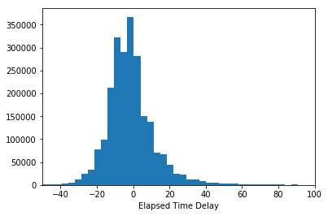

```python
# re-plot the histgram
plt.hist(data=flights, x="delay_elapsed",bins=200)
plt.xlabel("Elapsed Time Delay")
plt.xlim([-50,100]);
```

- delay_elapsed seems to be **more semmetric**, i.e. less right-skewed, compared to DepDelay. The mean and mode are around 0.
- the variance of delay_elapsed is also less than DepDelay, which makes sense as once the plane has took off, there's little room to deviate from scheduled in-air time.

### Analyzing the delay factor together

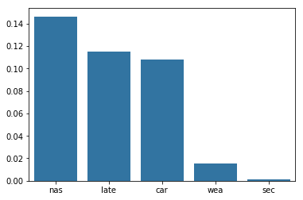

```python
# Identifying which type of delay causes most of the arrival delays:
p_car = flights[(~flights.CarrierDelay.isnull()) & (flights.CarrierDelay!=0)].shape[0]/flights.shape[0]
p_wea = flights[(~flights.WeatherDelay.isnull()) & (flights.WeatherDelay!=0)].shape[0]/flights.shape[0]
p_nas = flights[(~flights.NASDelay.isnull()) & (flights.NASDelay!=0)].shape[0]/flights.shape[0]
p_sec = flights[(~flights.SecurityDelay.isnull()) & (flights.SecurityDelay!=0)].shape[0]/flights.shape[0]
p_late = flights[(~flights.LateAircraftDelay.isnull()) & (flights.LateAircraftDelay!=0)].shape[0]/flights.shape[0]

delay_types = pd.Series([p_car,p_wea,p_nas,p_sec,p_late], index=["car","wea","nas","sec","late"]).sort_values(ascending=False)
sb.barplot(delay_types.index, delay_types, color=sb.color_palette()[0]);
```

- National Airspace System (NAS) related delays are the most frequent. This is not surprising as this is probably **broadest category** which includes delays related to the information systems, cargo services, rules, regulations, policies, procedures, personnel and equipment.

**Note:**

- more than one delay can cause an arrival delay
- the unspecified types of delays could be dumped into a NAS category, boosting up its portion

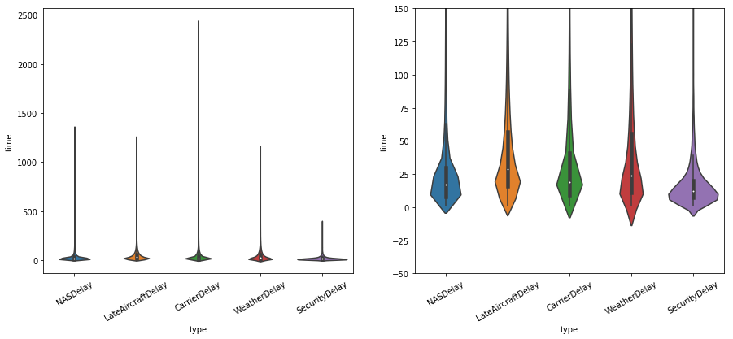

```python
# Let's look at the distribution of on how many minutes each delay factor can prolong the flight time
# First, create dummy dataframes with 2 columns, delay type and time
dummy = pd.DataFrame()
delay_types = ["NASDelay","LateAircraftDelay","CarrierDelay","WeatherDelay","SecurityDelay"]

for type in delay_types:
    dum = pd.DataFrame()
    dum["time"] = flights[(flights[type] != 0) & (~flights[type].isnull())][type]
    dum["type"] = type
    dummy = dummy.append(dum)

plt.figure(figsize=[15,6])
plt.subplot(1,2,1)
sb.violinplot(data= dummy, x="type", y="time")
plt.xticks(rotation=30);
plt.subplot(1,2,2)
sb.violinplot(data= dummy, x="type", y="time")
plt.ylim([-50,150])
plt.xticks(rotation=30);
```

### Discuss the distribution(s) of your variable(s) of interest. Were there any unusual points? Did you need to perform any transformations?

Distribution of the Departure delay is right-skewed with the mean about 0, which is more similar to the distribution of Arrival delay.  
Distribution of the Elapsed time delay is more symmetric with the mean about 0. Also, the variance of the Elapsed time delay is smaller than the variances of the former two.

To analyze the distributions and draw inferences:

- some outliers were removed from the data set
- the histograms were visualized using the log-scale
- the other delay types/factors' distributions were analysed using visual plots
- these plots suggest that larger portion of the delays are NAS related delays, which is, as discussed, could be a reasonable expectation
- the least relevant type/factor of the delay, to which smaller share of delays is attributed, will be dropped from the dataframe

### Of the features you investigated, were there any unusual distributions? Did you perform any operations on the data to tidy, adjust, or change the form of the data? If so, why did you do this?

- The outliers were looked for by analyzing the extreme values, first, on the distribution plots, then, close-up tables
- It was found that the extreme distances are related to the flights from/to Hawaii
- There were 3 significant "negative" delays in elapsed time which caused arrival delays, which does not make sense. Moreover, the actual time in the air for these flights were shorter than scheduled times. I assumed that these are related to emergency landing, and removed them as outliers.

## Bivariate Exploration

> It's a good idea to, first, look at the correlations between the variables in the dataset.

```python
flights1 = flights.copy()
numeric_vars = ["ArrDelay","delay_elapsed","DepDelay","Distance","AirTime","NASDelay","LateAircraftDelay","CarrierDelay","WeatherDelay"]
categoric_var = []
```

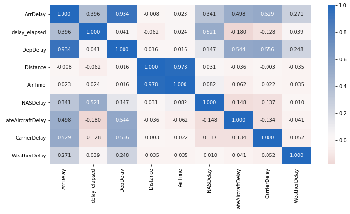

```python
# The correlation plot
plt.figure(figsize=[12,6])
sb.heatmap(flights1[numeric_vars].corr(), annot=True, fmt=".3f", cmap="vlag_r", center=0);
```

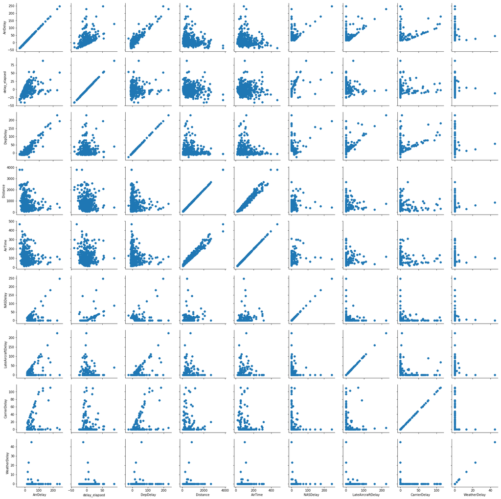

```python
# plot matrix : random sample of 1000 datapoints for the plots to look more clear and produce faster
samples = np.random.choice(flights1.shape[0], 500, replace=False)
flights1_sample = flights1.iloc[samples,:]

g = sb.PairGrid(data=flights1_sample, vars=numeric_vars)
#g = g.map_diag(plt.hist, bins = 30);
g.map(plt.scatter);
```

### Distance vs. AirTime

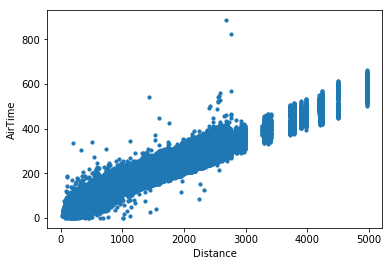

```python
plt.scatter(data=flights1, x="Distance", y="AirTime", s=10)
plt.xlabel("Distance")
plt.ylabel("AirTime");
```

> The two variables have strong correlation, however, there are some points to investigate:
> - AirTime with zero-value, where the Distance is non-zero
> - significantly different AirTime for the same Distances (around 2800-2900 miles).
1. Investigate the data points where AirTime and Distance don't correlate

```python
# Filter out short distances
flights1.nsmallest(5, "Distance")
```

|  | Month | DayofMonth | DayOfWeek | DepTime | CRSDepTime | ArrTime | CRSArrTime | UniqueCarrier | FlightNum | TailNum | ActualElapsedTime | CRSElapsedTime | AirTime | ArrDelay | DepDelay | Origin | Dest | Distance | TaxiIn | TaxiOut | CarrierDelay | WeatherDelay | NASDelay | SecurityDelay | LateAircraftDelay | depay_elapsed | delay_elapsed |
| --- | --- | --- | --- | --- | --- | --- | --- | --- | --- | --- | --- | --- | --- | --- | --- | --- | --- | --- | --- | --- | --- | --- | --- | --- | --- | --- | --- |
| 1688458 | 3 | 8 | 6 | NaN | 1105 | NaN | 1128 | AA | 1368 | NaN | NaN | 23.0 | NaN | NaN | NaN | EWR | LGA | 17 | NaN | NaN | NaN | NaN | NaN | NaN | NaN | NaN | NaN |
| 1087475 | 2 | 8 | 5 | NaN | 1910 | NaN | 1931 | AA | 1668 | NaN | NaN | 21.0 | NaN | NaN | NaN | FLL | MIA | 21 | NaN | NaN | NaN | NaN | NaN | NaN | NaN | NaN | NaN |
| 151795 | 1 | 2 | 3 | 1245 | 1025 | 1340 | 1125 | OH | 5610 | N806CA | 55.0 | 60.0 | 11.0 | 135.0 | 140.0 | IAD | DCA | 24 | 5.0 | 39.0 | 135.0 | 0.0 | 0.0 | 0.0 | 0.0 | -5.0 | -5.0 |
| 1637006 | 3 | 12 | 3 | 955 | 931 | 1021 | 948 | 9E | 2009 | 91619E | 26.0 | 17.0 | 10.0 | 33.0 | 24.0 | IAH | HOU | 24 | 7.0 | 9.0 | 0.0 | 0.0 | 9.0 | 0.0 | 24.0 | 9.0 | 9.0 |
| 797819 | 2 | 22 | 5 | 2046 | 2050 | NaN | 2156 | OO | 3698 | N298SW | NaN | 66.0 | NaN | NaN | -4.0 | SLC | OGD | 28 | NaN | 12.0 | NaN | NaN | NaN | NaN | NaN | NaN | NaN |

- The first two and the last entries might be invalid as the distances for airplanes to fly are too small and there are many missing data, such as AirTime. This might be **a good data cleaning point** -- as I am interested in the *flight* delays, I can drop the data points with null values for AirTime.

```python
# Drop flights with null values
flights1.dropna(subset=['AirTime'], inplace=True)
```

```python
flights1.nsmallest(5, "AirTime")
```

|  | Month | DayofMonth | DayOfWeek | DepTime | CRSDepTime | ArrTime | CRSArrTime | UniqueCarrier | FlightNum | TailNum | ActualElapsedTime | CRSElapsedTime | AirTime | ArrDelay | DepDelay | Origin | Dest | Distance | TaxiIn | TaxiOut | CarrierDelay | WeatherDelay | NASDelay | SecurityDelay | LateAircraftDelay | depay_elapsed | delay_elapsed |
| --- | --- | --- | --- | --- | --- | --- | --- | --- | --- | --- | --- | --- | --- | --- | --- | --- | --- | --- | --- | --- | --- | --- | --- | --- | --- | --- | --- |
| 171024 | 1 | 2 | 3 | 1258 | 1300 | 1408 | 1418 | OO | 3706 | N581SW | 70.0 | 78.0 | 0.0 | -10.0 | -2.0 | SGU | SLC | 269 | 4.0 | 66.0 | NaN | NaN | NaN | NaN | NaN | -8.0 | -8.0 |
| 174414 | 1 | 4 | 5 | 1700 | 1725 | 1801 | 1817 | OO | 3677 | N581SW | 61.0 | 52.0 | 0.0 | -16.0 | -25.0 | PIH | SLC | 150 | 58.0 | 3.0 | NaN | NaN | NaN | NaN | NaN | 9.0 | 9.0 |
| 176070 | 1 | 5 | 6 | 1318 | 1140 | 1456 | 1258 | OO | 3705 | N581SW | 98.0 | 78.0 | 0.0 | 118.0 | 98.0 | SGU | SLC | 269 | 96.0 | 2.0 | 0.0 | 0.0 | 0.0 | 0.0 | 118.0 | 20.0 | 20.0 |
| 177567 | 1 | 6 | 7 | 635 | 645 | 752 | 744 | OO | 3675 | N581SW | 77.0 | 59.0 | 0.0 | 8.0 | -10.0 | PIH | SLC | 150 | 75.0 | 2.0 | NaN | NaN | NaN | NaN | NaN | 18.0 | 18.0 |
| 177583 | 1 | 6 | 7 | 1414 | 1307 | 1547 | 1403 | OO | 3689 | N581SW | 93.0 | 56.0 | 0.0 | 104.0 | 67.0 | TWF | SLC | 175 | 90.0 | 3.0 | 0.0 | 104.0 | 0.0 | 0.0 | 0.0 | 37.0 | 37.0 |

```python
# Oops, even after dropping the null values, it seems that there are plenty of zero value entries for AirTime,
# which is still, technically, not a flight. To keep it more realistic, I will leave entries of flights with AirTime
# longer than 10 minutes
flights1 = flights1[flights1.AirTime > 10]
```

```python
flights1.nsmallest(5, "AirTime")
```

|  | Month | DayofMonth | DayOfWeek | DepTime | CRSDepTime | ArrTime | CRSArrTime | UniqueCarrier | FlightNum | TailNum | ActualElapsedTime | CRSElapsedTime | AirTime | ArrDelay | DepDelay | Origin | Dest | Distance | TaxiIn | TaxiOut | CarrierDelay | WeatherDelay | NASDelay | SecurityDelay | LateAircraftDelay | depay_elapsed | delay_elapsed |
| --- | --- | --- | --- | --- | --- | --- | --- | --- | --- | --- | --- | --- | --- | --- | --- | --- | --- | --- | --- | --- | --- | --- | --- | --- | --- | --- | --- |
| 136155 | 1 | 10 | 4 | 815 | 825 | 850 | 859 | YV | 1023 | N654BR | 35.0 | 34.0 | 11.0 | -9.0 | -10.0 | LIH | HNL | 102 | 5.0 | 19.0 | NaN | NaN | NaN | NaN | NaN | 1.0 | 1.0 |
| 151795 | 1 | 2 | 3 | 1245 | 1025 | 1340 | 1125 | OH | 5610 | N806CA | 55.0 | 60.0 | 11.0 | 135.0 | 140.0 | IAD | DCA | 24 | 5.0 | 39.0 | 135.0 | 0.0 | 0.0 | 0.0 | 0.0 | -5.0 | -5.0 |
| 157202 | 1 | 11 | 5 | 2105 | 2110 | 2132 | 2149 | OH | 5467 | N868CA | 27.0 | 39.0 | 11.0 | -17.0 | -5.0 | CVG | DAY | 64 | 7.0 | 9.0 | NaN | NaN | NaN | NaN | NaN | -12.0 | -12.0 |
| 169893 | 1 | 1 | 2 | 730 | 718 | 755 | 754 | OO | 5438 | N566SW | 25.0 | 36.0 | 11.0 | 1.0 | 12.0 | ONT | LAX | 47 | 3.0 | 11.0 | NaN | NaN | NaN | NaN | NaN | -11.0 | -11.0 |
| 169921 | 1 | 1 | 2 | 1736 | 1738 | 1804 | 1809 | OO | 5455 | N562SW | 28.0 | 31.0 | 11.0 | -5.0 | -2.0 | ONT | LAX | 47 | 7.0 | 10.0 | NaN | NaN | NaN | NaN | NaN | -3.0 | -3.0 |

### DepDelay vs. ElapsedTimeDelay

### DepDelay vs. ArrDelay

### ElapsedTimeDelay vs. ArrDelay

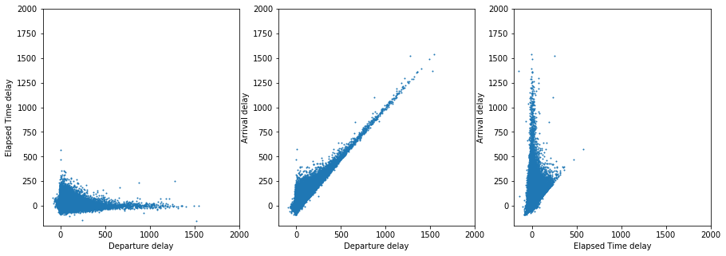

```python
plt.figure(figsize=[15,5])

plt.subplot(1,3,1)
plt.scatter(data=flights1, x="DepDelay", y="delay_elapsed", s=1)
plt.xlabel("Departure delay")
plt.ylabel("Elapsed Time delay");
plt.xlim([-200,2000])
plt.ylim([-200,2000]);

plt.subplot(1,3,2)
plt.scatter(data=flights1, x="DepDelay", y="ArrDelay", s=1)
plt.xlabel("Departure delay")
plt.ylabel("Arrival delay")
plt.xlim([-200,2000])
plt.ylim([-200,2000]);

plt.subplot(1,3,3)
plt.scatter(data=flights1, x="delay_elapsed", y="ArrDelay", s=1)
plt.xlabel("Elapsed Time delay")
plt.ylabel("Arrival delay")
plt.xlim([-200,2000])
plt.ylim([-200,2000]);
```

- The plot on the left is almost linear, meaning that delay_elapsed has very little effect on DepDelay, which is reasonable as time elapse starts when the plane departs, while DepDelay is the time delayed before starts the start of time elapse. Also, values of delay_elapsed are much smaller than DepDelay.
- The strong correlation between DepDelay and ArrDelay was discussed above.
- delay_elapsed, as can be seen in the plot, has very little effect on ArrDelay, hypothetically, becasue delays caused in air are very little compared to other factors.

### Distance vs. ArrDelay

### Distance vs. DepDelay

### Distance vs. ElapsedTimeDelay

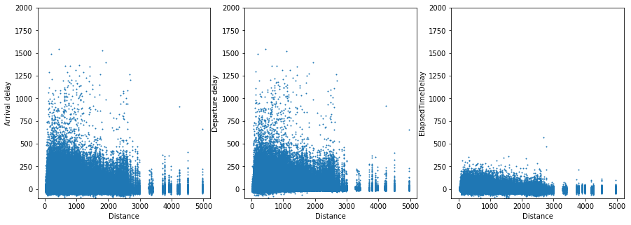

```python
plt.figure(figsize=[15,5])

plt.subplot(1,3,1)
plt.scatter(data=flights1, x="Distance", y="ArrDelay", s=1)
plt.xlabel("Distance")
plt.ylabel("Arrival delay")
plt.ylim([-100,2000]);

plt.subplot(1,3,2)
plt.scatter(data=flights1, x="Distance", y="DepDelay", s=1)
plt.xlabel("Distance")
plt.ylabel("Departure delay")
plt.ylim([-100,2000]);

plt.subplot(1,3,3)
plt.scatter(data=flights1, x="Distance", y="delay_elapsed", s=1)
plt.xlabel("Distance")
plt.ylabel("ElapsedTimeDelay")
plt.ylim([-100,2000]);
```

- Both DepDelay and delay_elapsed are more prevelent in shorter distance flights. Which might be a surprising result (or maybe long distance flights have more *preparation*, hence more *robust* following the schedule)
- Consequently, ArrDelay is also larger for shorter distances.
- This result also might be caused by the rarity of long-distance flights.

```python
# Creating a dummy dataframe with 4 columns for delay type, delay time, DepDelay, delay_elapsed
dummy2 = pd.DataFrame()
delay_types = ["NASDelay","LateAircraftDelay","CarrierDelay","WeatherDelay"]

for type in delay_types:
    dum = pd.DataFrame()
    dum["time"] = flights1[(flights1[type] != 0) & (~flights1[type].isnull())][type]
    dum["DepDelay"] = flights1[(flights1[type] != 0) & (~flights1[type].isnull())]["DepDelay"]
    dum["delay_elapsed"] = flights1[(flights1[type] != 0) & (~flights1[type].isnull())]["delay_elapsed"]
    dum["ArrDelay"] = flights1[(flights1[type] != 0) & (~flights1[type].isnull())]["ArrDelay"]
    dum["Distance"] = flights1[(flights1[type] != 0) & (~flights1[type].isnull())]["Distance"]
    dum["type"] = type
    dummy2 = dummy2.append(dum)
```

### Distance vs. the four delay factors

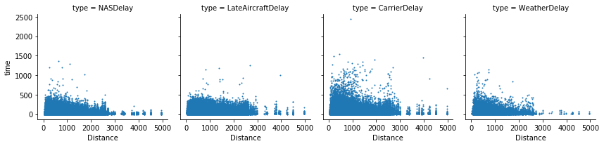

```python
g = sb.FacetGrid(data=dummy2, col="type")
g.map(plt.scatter, "Distance", "time", s=1);
```

- The distance doesn't seem to be a significant factor for delay

### ElapsedTimeDelay vs. the four delay factors

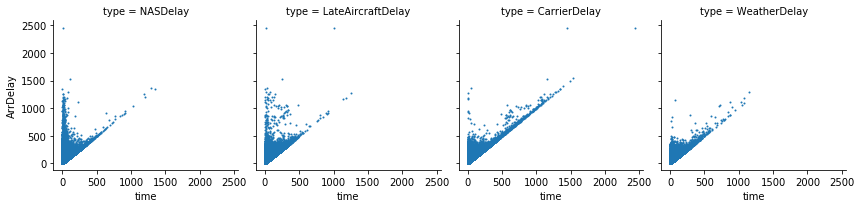

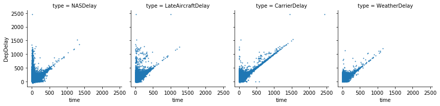

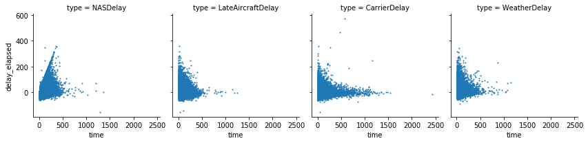

```python
#plt.figure(figsize=[15,15])

#plt.subplot(3,1,1)
g = sb.FacetGrid(data=dummy2, col="type")
g.map(plt.scatter, "time", "ArrDelay", s=1);

#plt.subplot(3,1,2)
g = sb.FacetGrid(data=dummy2, col="type")
g.map(plt.scatter, "time", "DepDelay", s=1);

#plt.subplot(3,1,3)
g = sb.FacetGrid(data=dummy2, col="type")
g.map(plt.scatter, "time", "delay_elapsed", s=1);
```

## Multivariate Exploration

```python
# Copy the dataframe
df_multivar = flights1.copy()
```

```python
# make dummy dataframe which has 5 columns, delay type, delay time, DepDelay, delay_elapsed, distance

dummy3 = pd.DataFrame()
delay_types = ["NASDelay","LateAircraftDelay","CarrierDelay","WeatherDelay"]

for type in delay_types:
    dum = pd.DataFrame()
    dum["time"] = df_multivar[(df_multivar[type] != 0) & (~df_multivar[type].isnull())][type]
    dum["DepDelay"] = df_multivar[(df_multivar[type] != 0) & (~df_multivar[type].isnull())]["DepDelay"]
    dum["delay_elapsed"] = df_multivar[(df_multivar[type] != 0) & (~df_multivar[type].isnull())]["delay_elapsed"]
    dum["ArrDelay"] = df_multivar[(df_multivar[type] != 0) & (~df_multivar[type].isnull())]["ArrDelay"]
    dum["Distance"] = df_multivar[(df_multivar[type] != 0) & (~df_multivar[type].isnull())]["Distance"]
    dum["type"] = type
    dummy3 = dummy3.append(dum)
```

## Finding1 - The longer the delay_elapsed is, the longer NASdelay is.

### Elapsed time delay blocks

> The flight data will be divided into two, by the length of delay_elapsed. The analysis will be on how much time of the delay the factors account for, depending on the Distance in each part of delay_elapsed.
- NASDelay. According to the plot the flights for which elapsed time is 200 and 400 minutes are more likely to have longer NASdelay time.

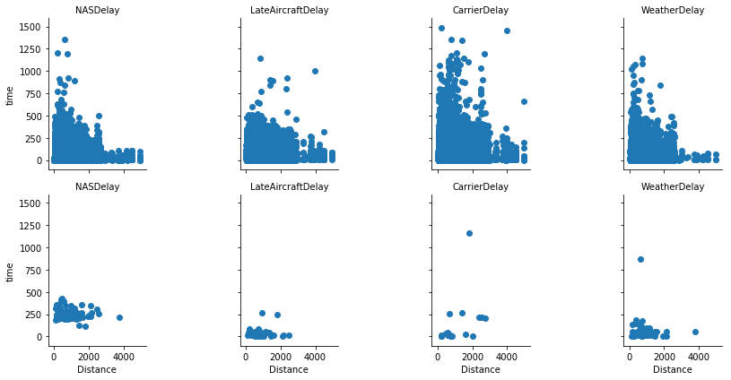

```python
bin_edges = np.arange(0,600,200)
dummy3["elapsed_blocked"] = pd.cut(dummy3.delay_elapsed, bin_edges, right=False, include_lowest=True)
g = sb.FacetGrid(data=dummy3, row="elapsed_blocked", col="type" )
g.map(plt.scatter, "Distance", "time")
g.set_titles('{col_name}');
```

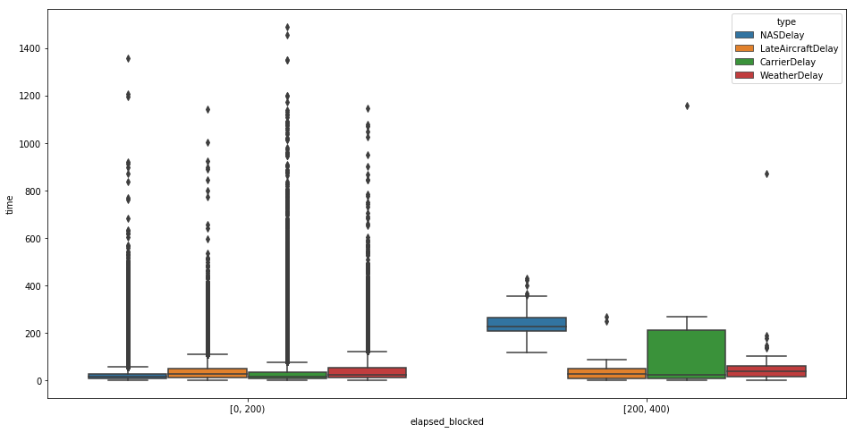

```python
plt.figure(figsize=[16,8])
sb.boxplot(data=dummy3, hue="type", y="time", x="elapsed_blocked");
```

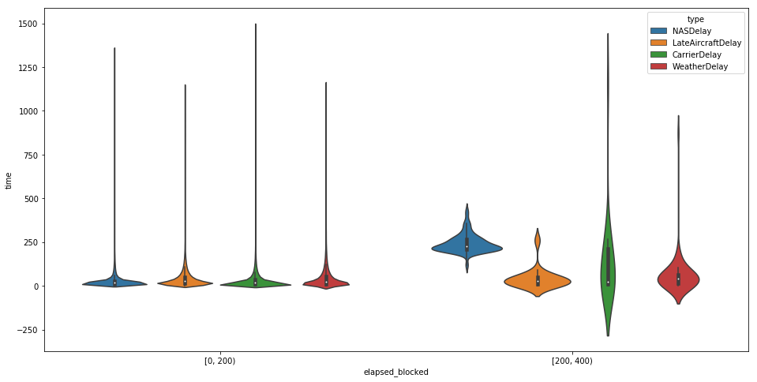

```python
plt.figure(figsize=[16,8])
sb.violinplot(data=dummy3, hue="type", y="time", x="elapsed_blocked");
```

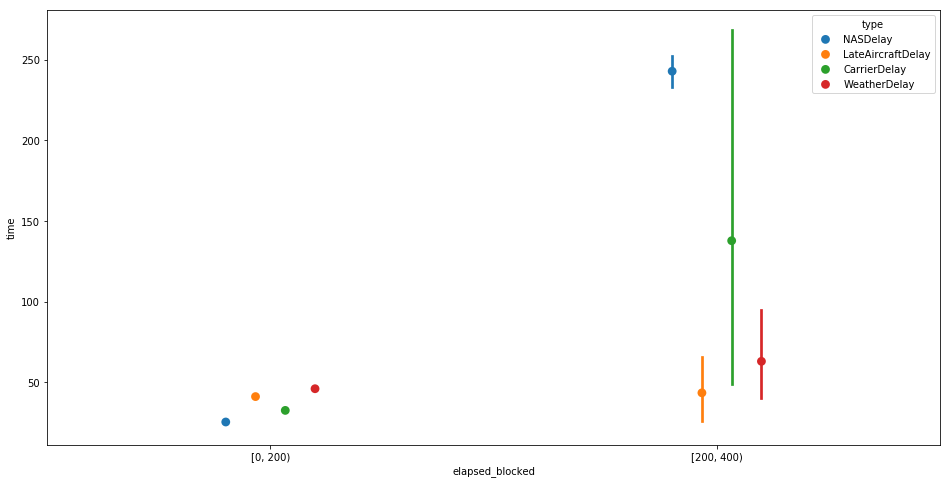

```python
plt.figure(figsize=[16,8])
sb.pointplot(data=dummy3, hue="type", y="time", x="elapsed_blocked", linestyles="", dodge=0.2);
```

## Finding 2 - The longer DepDelay is, the longer CarrierDelay is

### DepDelay blocks

> The flight data is divided into 4 parts according to the length of DepDelay. The visual analysis will focus on how many minutes of the delay is attributed to each of the 4 factors, depending on the Distance.

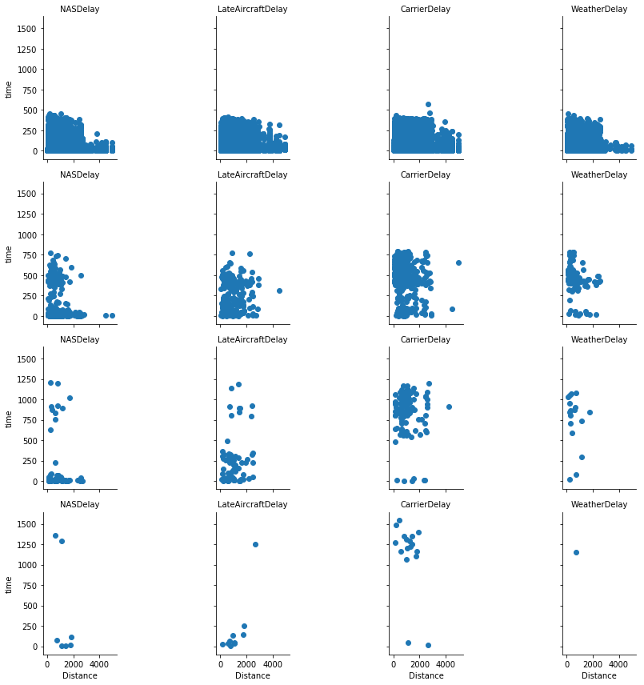

```python
bin_edges = np.arange(0,2000,400)
dummy3["depdelay_blocked"] = pd.cut(dummy3.DepDelay, bin_edges, right=False, include_lowest=True)
g = sb.FacetGrid(data=dummy3, row="depdelay_blocked", col="type" )
g.map(plt.scatter, "Distance", "time")
g.set_titles('{col_name}');
```

```python
dummy3["distance_block"] = pd.cut(dummy3.Distance, bin_edges, right=False, include_lowest=True)
```

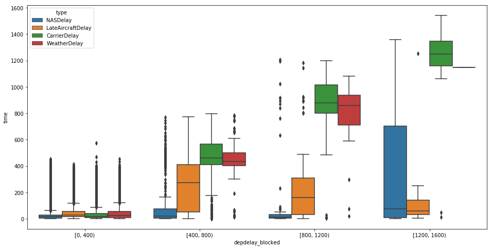

```python
plt.figure(figsize=[16,8])
sb.boxplot(data=dummy3, hue="type", y="time", x="depdelay_blocked");
```

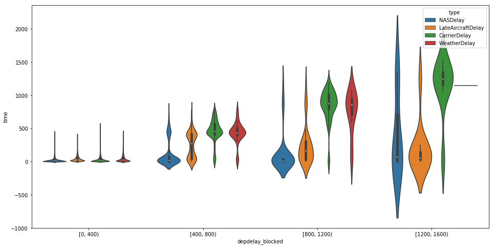

```python
plt.figure(figsize=[16,8])
sb.violinplot(data=dummy3, hue="type", y="time", x="depdelay_blocked");
```

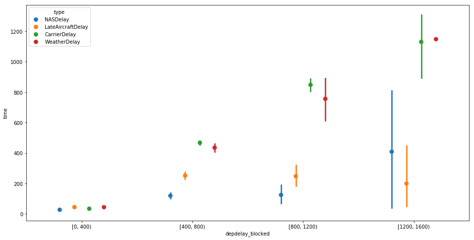

```python
plt.figure(figsize=[16,8])
sb.pointplot(data=dummy3, hue="type", y="time", x="depdelay_blocked", linestyles="", dodge=0.4);
```

- For CarrierDelay and WeatherDelay, the longer the DepDelay time is, the more likely that it CarrierDelay and LateAir have delays (i.e DepDelay might be caused by those factors).

### Distance bocks

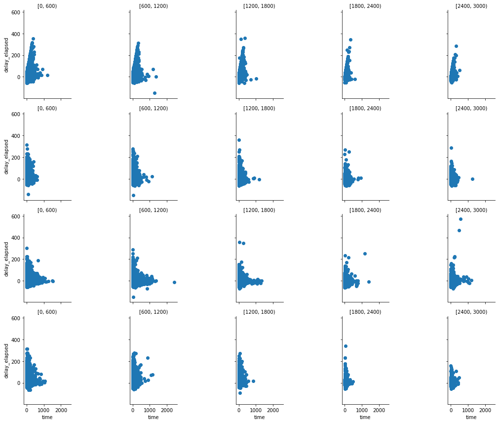

```python
bin_edges = np.arange(0,3600,600)
dummy3["distance_block"] = pd.cut(dummy3.Distance, bin_edges, right=False, include_lowest=True)
g = sb.FacetGrid(data=dummy3, col="distance_block", row="type")
g.map(plt.scatter, "time", "delay_elapsed")
g.set_titles('{col_name}');
```

### Talk about some of the relationships you observed in this part of the investigation. Were there features that strengthened each other in terms of looking at your feature(s) of interest?

- It was found that the Distance does not have a big effect on DepDelay.
- It was also found that the flights with delay_elapsed between 200 and 400 minutes are more likely to have longer NASdelay time.
- As for delay_elapsed, the longer the DepDelay is, the longer CarrierDelay and WeatherDelay are likely to be.

### Were there any interesting or surprising interactions between features?

- Given the definition of NASDelay above, it's interesting to observe that longer deley_elapsed is associated with with longer NASDelay. This might be due to system, procedures and regulations due to which a plane is not able to depart on time.
- Regarding CarrierDelay and WeatherDelay, they are less likely to occur, however they are stronger associated with longer DepDelay.